# Activity: Street or Road?

# 5. `!grepl(" BOX ", address))`: This part also filters out addresses that contain ” BOX “.

#### Part 2: Implement your method on the entire `Addresses` data set. Explain how your code works line by line.

```r
# Define the pattern to match street endings
pattern <- "(ST|RD|ROAD|AVE|BLVD|CIR|DR|LN|PL|WAY|CT|PKWY|TRL|TER)"

# Filter out addresses that do not match the pattern, contain "APT" or "UNIT", or " BOX "
LeftOvers <- Addresses %>%
  filter( !grepl(pattern, address),
          !grepl("\\sAPT|UNIT\\s[\\d]+$", address),
          !grepl(" BOX ", address)
          )

# Extract the matched street endings
StreetEndings <- Addresses %>%
  filter(grepl(pattern, address)) %>%
  mutate(street_ending = str_extract(address, pattern))

# Display the unique street endings
unique_street_endings <- StreetEndings %>%
  count(street_ending, sort = TRUE)

# Display the result
kable(unique_street_endings)
```

| street_ending | n |
| --- | --- |
| ST | 893 |
| DR | 755 |
| RD | 732 |
| AVE | 267 |
| CT | 211 |
| ROAD | 187 |
| LN | 151 |
| PL | 150 |
| WAY | 137 |
| CIR | 105 |
| TER | 96 |
| BLVD | 42 |
| PKWY | 27 |
| TRL | 13 |

```r
NA
NA
```

#My answer here……. # I explained all the code in the comments above

#### Additional Question 1: Present your result from part 2 by providing a table in descending order of popularity for the street name endings you found

```r
# Display the table
kable(unique_street_endings)
```

| street_ending | n |
| --- | --- |
| ST | 893 |
| DR | 755 |
| RD | 732 |
| AVE | 267 |
| CT | 211 |
| ROAD | 187 |
| LN | 151 |
| PL | 150 |
| WAY | 137 |
| CIR | 105 |
| TER | 96 |
| BLVD | 42 |
| PKWY | 27 |
| TRL | 13 |

```r
NA
NA
```

#### Additional Question 2: Present your result by using ggplot to a bar chart in descending order of popularity for the street name endings you found previously.

Note: make sure your order street names according to popularity, not alphabetically.

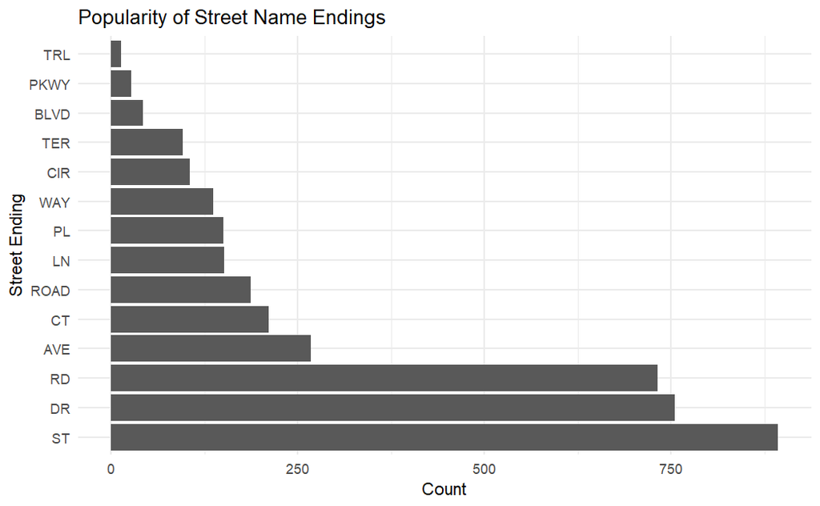

```r
ggplot(unique_street_endings, aes(x = reorder(street_ending, -n), y = n)) +
  geom_bar(stat = "identity") +
  coord_flip() +
  labs(title = "Popularity of Street Name Endings",
       x = "Street Ending",
       y = "Count") +
  theme_minimal()
```

```r
NA
NA
```

#### Additional Question 3: Comment on any patterns you see

# My answer here:

# The bar chart shows that certain street endings, such as “RD”, “DR”, and “ST”, are significantly more common than others. This means that these types of streets are more prevalent in the dataset. Less common endings like “TRL”, “BLVD”, and “PKWY” are used less frequently, meaning they may be less common types of streets or specific to certain areas.